# R Notebook

### Heatmap

```r
if (!requireNamespace("reshape2", quietly = TRUE)) {install.packages("reshape2")}
library(reshape2)
```

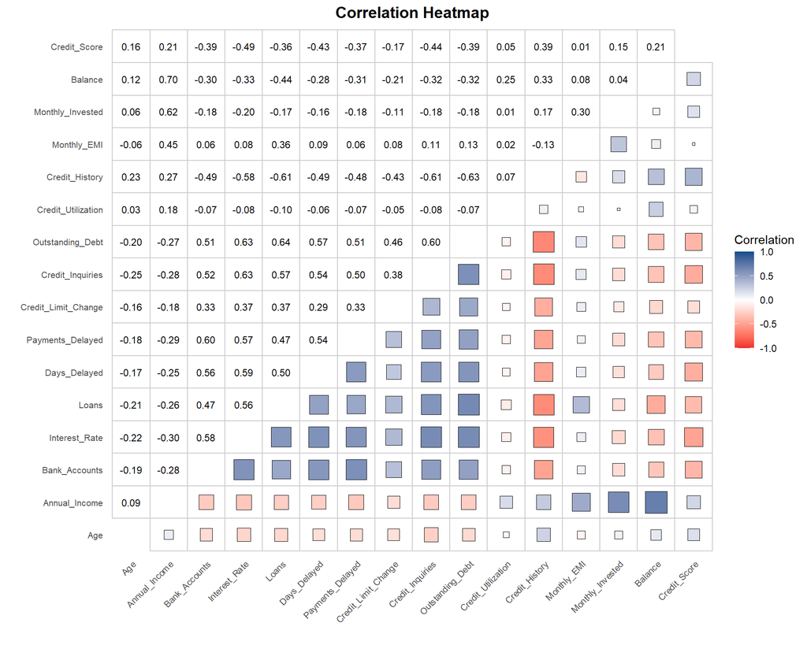

```r
library(ggplot2)

df_plotting <- df_numeric

corr_matrix <- round(cor(df_plotting),2)
melted_corr_mat <- melt(corr_matrix)

melted_corr_mat <- melted_corr_mat[melted_corr_mat$Var1 != melted_corr_mat$Var2, ]
lower_triangle <- melted_corr_mat[as.numeric(melted_corr_mat$Var1) >= as.numeric(melted_corr_mat$Var2), ]
upper_triangle <- melted_corr_mat[as.numeric(melted_corr_mat$Var1) < as.numeric(melted_corr_mat$Var2), ]

ggplot() +
  geom_tile(data = melted_corr_mat, aes(x = Var1, y = Var2), fill = 'white', col = 'grey80', linewidth = 0.5, alpha = 0.4) +
  geom_point(data = lower_triangle, aes(x = Var1, y = Var2, fill = value, size = abs(value)), shape = 22, color = "black") +
  geom_text(data = upper_triangle, aes(x = Var1, y = Var2, label = sprintf("%.2f", value)), size = 3, color = "black") +
  scale_fill_gradient2(
    low = "firebrick2", high = "dodgerblue4", mid = "white",
    midpoint = 0, limit = c(-1, 1), space = "Lab", name = "Correlation"
  ) +
  scale_size(range = c(1, 10), guide = "none") +
  theme_minimal() +
  theme(
    axis.text.x = element_text(angle = 45, vjust = 1, hjust = 1),
    axis.text = element_text(size = 8),
    plot.title = element_text(hjust = 0.5, size = 14, face = "bold"),
    panel.grid.minor = element_blank(),
    panel.grid.major = element_blank()
  ) +
  labs(
    title = "Correlation Heatmap",
    x = "", y = ""
  )
```

This heatmap shows the correlation between the different variables. In order to answer our research question the variable that is the most interesting is “credit_score”. The variable that has the most (negative) impact is interest_rate with a correlation of -0.49. The variable credit_inquiries is also “highly” negatively correlated with the credit score.

## Categorical Variables

```r
df_categorical <- df[, c("Occupation", "Credit_Mix", "Min_Payment", "Payment_Behaviour", "Credit_Score")]

str(df_categorical)
```

```
## tibble [100,000 × 5] (S3: tbl_df/tbl/data.frame)
##  $ Occupation       : Factor w/ 15 levels "Accountant","Architect",..: 13 13 13 13 13 13 13 13 14 14 ...
##  $ Credit_Mix       : Factor w/ 3 levels "Poor","Standard",..: 3 3 3 3 3 3 3 3 3 3 ...
##  $ Min_Payment      : Factor w/ 2 levels "No","Yes": 1 1 1 1 1 1 1 1 1 1 ...
##  $ Payment_Behaviour: Factor w/ 6 levels "LowSpent_SmallValue",..: 4 3 2 1 5 1 1 5 1 6 ...
##  $ Credit_Score     : Factor w/ 3 levels "Poor","Standard",..: 3 3 3 3 3 3 3 2 2 3 ...
```

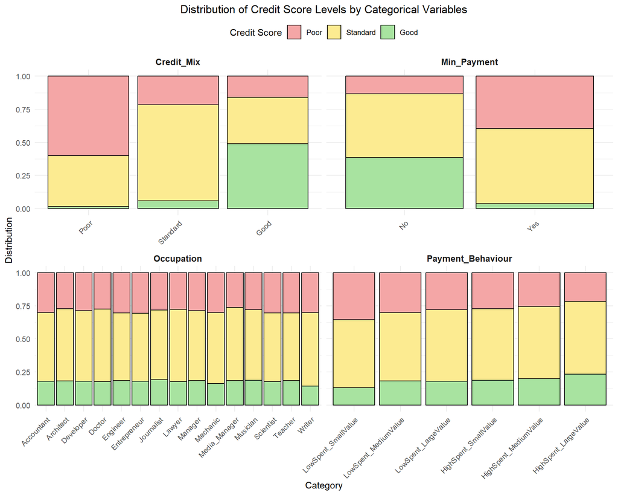

```r
library(ggplot2)
library(tidyr)

df_long_categorical <- df_categorical %>%
  pivot_longer(
    cols = -Credit_Score,
    names_to = "Variable",
    values_to = "Category"
  )

# Create the faceted barplot
ggplot(df_long_categorical, aes(x = Category, fill = Credit_Score)) +
  geom_bar(position = "fill", color = "black") +   # Proportional bars
  facet_wrap(~Variable, scales = "free_x") +      # One facet per categorical variable
  labs(
    title = "Distribution of Credit Score Levels by Categorical Variables",
    x = "Category",
    y = "Distribution",
    fill = "Credit Score"
  ) +
  scale_fill_manual(values = c("Poor" = "#F4A6A6", "Standard" = "#FCEB91", "Good" = "#A8E3A0")) +
  theme_minimal() +
  theme(
    axis.text.x = element_text(angle = 45, hjust = 1),  # Rotate x-axis labels for readability
    legend.position = "top",                           # Place legend at the top
    strip.text = element_text(size = 10, face = "bold"), # Improve facet labels
    plot.title = element_text(hjust = 0.5)
  )
```

This chart provides a visual breakdown of credit scores based on various categorical variables. The credit scores are divided into three categories: Poor, Standard, and Good. The visualization is organized into four distinct sections based on the variables Credit_Mix, Min_Payment, Occupation, and Payment_Behaviour.

**Credit_Mix**

**Min_Payment**

**Occupation**

**Payment_Behaviour**

- For individuals with LowSpent behaviors, whether the purchase value is Small, Medium, or Large, there is a consistent distribution with Standard credit scores dominating, followed by Poor credit scores and a smaller fraction of Good scores.
- Those with HighSpent behaviors (spending higher amounts) similarly show predominance of Standard credit scores, but the distribution of Poor and Good scores varies slightly, with Good scores being a bit more prominent than in the LowSpent categories.

# Model Building

We will be building 4 models to classify a customer into the Credit Score categories.

1. Multinomial Logistic Regression
2. Ordinal Logistic Regression
3. Decision Tree (Pruned)
4. Random Forest

## Train and Test Split

```r
set.seed(1234)
n <- nrow(df)
n1 <- 0.8*n
ind <- sample(1:n, n1)
train_data <- df[ind,]
test_data <- df[-ind,]
```

## Baseline: Majority Classifier

The baseline accuracy which the model should outperform is in this case 53.1%, which is the case, when every observation gets classified as Standard, which is the majority Class.

```r
# Show the counts of each class
class_counts <- table(train_data$Credit_Score)

# Show the proportions of each class
class_proportions <- prop.table(class_counts)

class_proportions_df <- data.frame(
  Class = names(class_proportions),
  Proportion = as.numeric(class_proportions)
)

print(class_proportions_df)
```

```
##      Class Proportion
## 1     Poor  0.2901125
## 2 Standard  0.5309250
## 3     Good  0.1789625
```

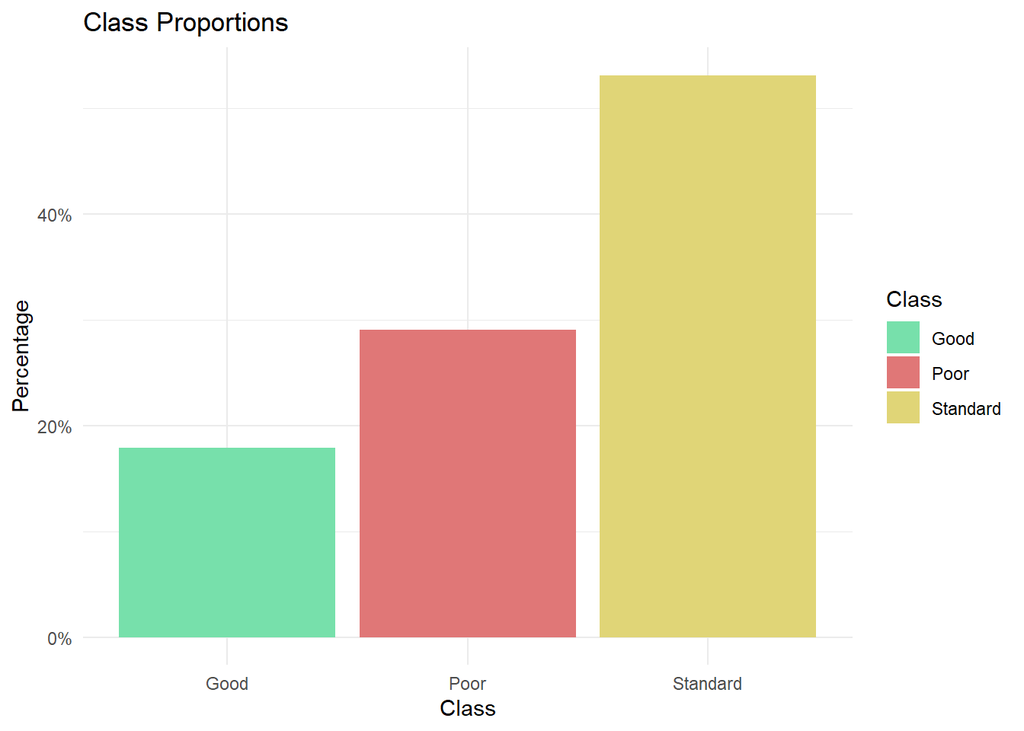

```r
ggplot(class_proportions_df, aes(x = Class, y = Proportion, fill = Class)) +
  geom_bar(stat = "identity") +
  labs(
    title = "Class Proportions",
    x = "Class",
    y = "Percentage"
  ) +
  theme_minimal() +
  scale_y_continuous(labels = scales::percent) +
  scale_fill_manual(values = c("Good" = "#77e0ab", "Poor" = "#e07777", "Standard" = "#e0d577"))
```

## Multinomial Logistic Regression

Multinomial Logistic Regression is a statistical method used to classify a dependent variable with more than two categories. Here with “Credit Score” (Poor, Standard, Good). It predicts the likelihood of each category based on the values of multiple numeric and categorical predictor variables.

Here’s how it works:

1. Baseline Category: One category is chosen as the reference (baseline). In this case, it’s “Poor.”
2. Log-Odds Comparison: The model calculates the log-odds (logarithm of the odds) of being in each of the other categories (Standard, Good) compared to the baseline.
3. Coefficients: It estimates coefficients for each predictor variable, which represent how much the predictor increases or decreases the log-odds of being in a category compared to the baseline.
4. Prediction: Using the coefficients, the model predicts probabilities for each class (Poor, Standard, Good) for a given set of predictor values. The class with the highest probability is chosen as the prediction.

In R `multinom()` automatically handles the baseline and estimates the coefficients for all predictors.

This model is especially useful when the outcome has multiple categories, and you want to understand how predictors influence the likelihood of each class, which is what we want in this case.

We also tried to do a stepwise with this model using `stepAIC(model_mlogit, direction = "both"),` but this only resulted in marginal improvements and took really long to calculate. That’s why we left it out of this report.

```r
if (!requireNamespace("nnet", quietly = TRUE)) {install.packages("nnet")}
if (!requireNamespace("MASS", quietly = TRUE)) {install.packages("MASS")}

library(nnet)
library(MASS)
model_mlogit <- multinom(Credit_Score ~ ., data = train_data)
#summary(model_mlogit)
```

## Ordinal Logistic Regression

Ordinal Logistic Regression is used when the dependent variable has ordered categories, like here “Credit Score” (Poor < Standard < Good). Unlike Multinomial Logistic Regression, this model takes the order of the categories into account.

1. Ordered Categories: The model assumes that the categories have a natural order (e.g., Poor < Standard < Good).
2. Cumulative Log-Odds: It calculates the cumulative log-odds of being in a category *or below* it (e.g., Poor or Standard vs. Good).
3. Thresholds: The model estimates thresholds (cut-points) that define where one category ends, and the next begins.
4. Predictor Effects: It estimates coefficients for each predictor variable, showing how much they increase or decrease the likelihood of being in a higher category.
5. Prediction: For a given set of predictor values, the model predicts the probabilities of each category while respecting their order.

In R code, using `polr()` and setting the `Credit_Score` as an ordered factor ensures the model knows the categories are ordinal. The `Hess = TRUE` option computes the Hessian matrix, which is useful for hypothesis testing and confidence intervals.

This model is ideal when the response variable is ordinal, as it makes better use of the order information compared to models like Multinomial Logistic Regression.

Same as above a stepwise model was tried, but it didn’t yield and meaningful improvements other than 15 minutes of computing.

**Preparing the data**

```r
train_data_ordered <- train_data
test_data_ordered <- test_data

# https://stackoverflow.com/questions/75892750/ordinal-logistic-regression-error-in-svdx-infinite-or-missing-values-in-x
# > summary(model_ordinal) Fehler in svd(X) : unendliche oder fehlende Werte in 'x'
train_data_ordered$Annual_Income <- train_data_ordered$Annual_Income / 1000
test_data_ordered$Annual_Income <- test_data_ordered$Annual_Income / 1000

train_data_ordered$Credit_Score <- factor(train_data_ordered$Credit_Score, levels = c("Poor", "Standard", "Good"), ordered = TRUE)
test_data_ordered$Credit_Score <- factor(test_data_ordered$Credit_Score, levels = c("Poor", "Standard", "Good"), ordered = TRUE)
```

**Building the model**

```r
library(MASS)

model_ordinal <- polr(Credit_Score ~ ., data = train_data_ordered, Hess = TRUE)
#summary(model_ordinal)
```

## Decision Tree

### Standard

A Decision Tree is a simple and intuitive model that can be used for classification tasks, like here predicting “Credit Score” (Poor, Standard, Good). It works by splitting the data into smaller and smaller groups based on the predictor variables to make predictions.

1. Splitting the Data: The model starts at the top (the root) and splits the data into groups using the predictor variables, choosing splits that best separate the classes.
2. Rules at Each Node: At each split (node), a decision rule is applied, like “Income > 50,000?” or “Age <= 35?” to divide the data into branches.
3. Class Assignment: At the end of each branch (leaf), the model assigns the most frequent class (e.g., Poor, Standard, or Good) based on the data in that leaf.
4. Prediction: For a new observation, the model follows the decision rules down the tree to assign it to a class.

In R code, `rpart()` builds the decision tree using “class” mode, which is for classification tasks. The tree learns rules to classify “Credit Score” based on your predictor variables.

Decision Trees are powerful because they are easy to interpret and handle both numeric and categorical variables. However, they can overfit, so pruning may be necessary for better generalization.

```r
if (!requireNamespace("rpart", quietly = TRUE)) {install.packages("rpart")}
if (!requireNamespace("rpart.plot", quietly = TRUE)) {install.packages("rpart.plot")}

library(rpart)
library(rpart.plot)

model_tree <- rpart(Credit_Score ~ ., data = train_data, method = "class")

#summary(model_tree)
```

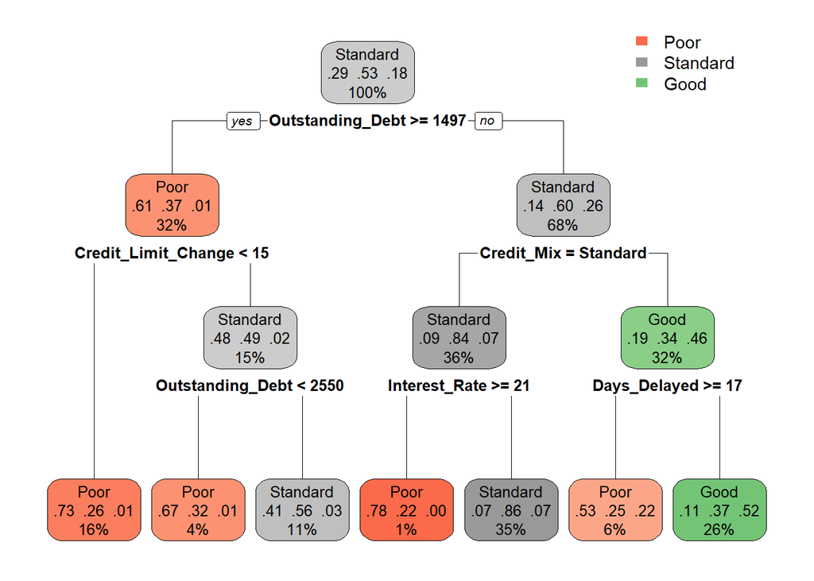

```r
rpart.plot(model_tree)
```

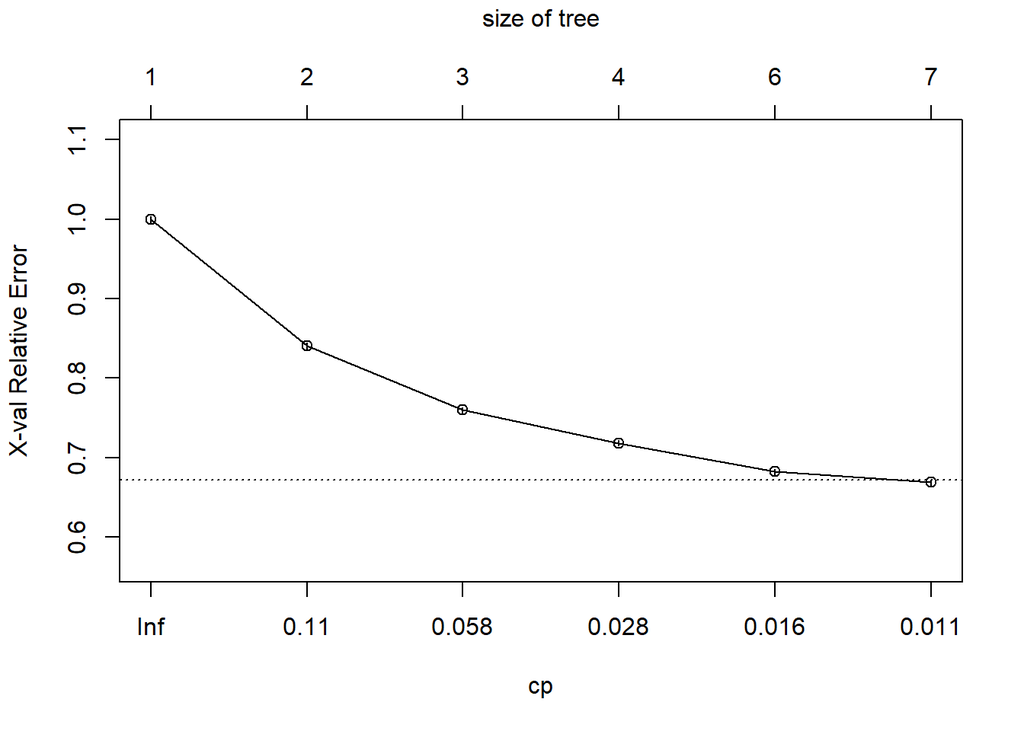

```r
plotcp(model_tree)
```

**Decision Tree Graph**

This decision tree graph visually represents a model that classifies outcomes into three categories: Poor, Standard, and Good based on various credit-related variables. Each node shows the classification split with probability scores and the percentage of samples falling into each category. The splits are determined by conditions related to variables like Outstanding_Debt, Credit_Limit_Change, Credit_Mix, Interest_Rate, and Days_Delayed.

Summary:

- High Outstanding Debt (≥ 1497) → Poor credit score.
- Low Outstanding Debt combined with Credit Mix or Days Delayed increases the likelihood of Standard or Good credit scores.
- Important variables: Outstanding Debt, Credit Limit Change, Interest Rate, Days Delayed.

### Pruned

In this case pruning did not improve the results, because the pruned tree is identical to the original Tree.

```r
optimal_cp <- model_tree$cptable[which.min(model_tree$cptable[,"xerror"]), "CP"]
print(optimal_cp)
```

```
## [1] 0.01
```

```r
model_tree_pruned <- prune(model_tree, cp = optimal_cp)
```

## Random Forest

Random Forest is an ensemble model that builds multiple decision trees to improve classification accuracy and reduce overfitting. It can handle both numeric and categorical predictors.

1. Multiple Trees:  
   The model builds many decision trees using random subsets of the data and predictor variables.
2. Voting for Prediction:  
   For classification (like Credit Score), each tree predicts a class (Poor, Standard, Good). The final prediction is the class with the most votes.
3. Probability Estimates:  
   By setting `probability = TRUE`, the model outputs the probabilities for each class (e.g., 70% Poor, 20% Standard, 10% Good).
4. Variable Importance:  
   With `importance = "permutation"`, the model calculates how much each predictor variable contributes to the accuracy of the predictions.

In R code, `ranger()` builds the Random Forest model efficiently for the Credit Score prediction task.

```r
if (!requireNamespace("ranger", quietly = TRUE)) {install.packages("ranger")}
library(ranger)

set.seed(1234)
model_randomforest <- ranger(Credit_Score ~ ., data = train_data, probability = TRUE, importance = "permutation")
#summary(model_randomforest)
```

### Importance Scores

The importance scores in a Random Forest measure how much each predictor variable contributes to the model’s accuracy. Higher scores indicate that a variable plays a larger role in correctly predicting the target outcome by improving splits across the trees.

The results will be discussed further down the line.

```r
library(dplyr)

importance_forest <- importance(model_randomforest)

importance_table <- data.frame(
  Variable = names(importance_forest),
  Importance = as.numeric(importance_forest)
)

importance_table <- importance_table %>%
  arrange(desc(Importance))

importance_table
```

| Variable | Importance |
| --- | --- |
| Credit_Mix | 0.111591507 |
| Outstanding_Debt | 0.097934016 |
| Interest_Rate | 0.094064502 |
| Days_Delayed | 0.075050874 |
| Credit_History | 0.052538772 |
| Annual_Income | 0.048854511 |
| Monthly_EMI | 0.044767520 |
| Credit_Limit_Change | 0.041866251 |
| Bank_Accounts | 0.041440197 |
| Credit_Inquiries | 0.038771135 |

[output cut: 9 more lines]

# Model Evaluation

For model evaluation we use the accuracy and macro average the precision, recall and f1 scores, because the results are not binary. Also the confusion matrix will be displayed for each model.

## Multinomial Logistic Regression

```r
predicted_mlogit <- predict(model_mlogit, newdata = test_data, type = "class")

# Confusion matrix
mlogit_confmatrix <- table(Predicted = predicted_mlogit, Actual = test_data$Credit_Score)

# Accuracy
accuracy_mlogit <- mean(predicted_mlogit == test_data$Credit_Score)

# Precision for each class
precision_per_class <- diag(mlogit_confmatrix) / rowSums(mlogit_confmatrix)

# Recall for each class
recall_per_class <- diag(mlogit_confmatrix) / colSums(mlogit_confmatrix)

# F1-Score for each class
f1_per_class <- 2 * (precision_per_class * recall_per_class) / (precision_per_class + recall_per_class)

# Macro-averaged scores
precision_mlogit <- mean(precision_per_class, na.rm = TRUE)
recall_mlogit <- mean(recall_per_class, na.rm = TRUE)
F1_mlogit <- mean(f1_per_class, na.rm = TRUE)

mlogit_results <- data.frame(
  Metric = c("Accuracy", "Precision", "Recall", "F1 Score"),
  Value = c(accuracy_mlogit, precision_mlogit, recall_mlogit, F1_mlogit)
)

print(mlogit_confmatrix)
```

```
##           Actual
## Predicted  Poor Standard Good
##   Poor     3145     1509   88
##   Standard 1984     7511  899
##   Good      660     1680 2524
```

```r
print(mlogit_results)
```

```
##      Metric     Value
## 1  Accuracy 0.6590000
## 2 Precision 0.6349217
## 3    Recall 0.6547059
## 4  F1 Score 0.6373920
```

- Accuracy: 65.9% - The model correctly predicts the Credit Score 65.9% of the time.
- Precision: 63.5% - When the model predicts a class, 63.5% of those predictions are correct.
- Recall: 65.5% - The model captures 65.5% of all actual cases across the classes.
- F1 Score: 63.7% - A balance between precision and recall, indicating moderate performance.

**Justification**:

Multinomial Logistic Regression works well for classifying multiple categories but assumes a linear relationship between predictors and log-odds. The moderate scores suggest the model is capturing some patterns but struggles with complex relationships or overlaps between classes like “Standard” and “Good”. This may explain why accuracy and recall are only moderately high.

## Ordinal Logistic Regression

```r
predicted_ordinal <- predict(model_ordinal, newdata = test_data_ordered, type = "class")

# Confusion matrix
ordinal_confmatrix <- table(Predicted = predicted_ordinal, Actual = test_data_ordered$Credit_Score)

# Accuracy
accuracy_ordinal <- mean(as.character(predicted_ordinal) == as.character(test_data_ordered$Credit_Score))

# Precision for each class
precision_per_class_ordinal <- diag(ordinal_confmatrix) / rowSums(ordinal_confmatrix)

# Recall for each class
recall_per_class_ordinal <- diag(ordinal_confmatrix) / colSums(ordinal_confmatrix)

# F1-Score for each class
f1_per_class_ordinal <- 2 * (precision_per_class_ordinal * recall_per_class_ordinal) /
                        (precision_per_class_ordinal + recall_per_class_ordinal)

# Macro-averaged scores
precision_ordinal <- mean(precision_per_class_ordinal, na.rm = TRUE)
recall_ordinal <- mean(recall_per_class_ordinal, na.rm = TRUE)
F1_ordinal <- mean(f1_per_class_ordinal, na.rm = TRUE)

ordinal_results <- data.frame(
  Metric = c("Accuracy", "Precision", "Recall", "F1 Score"),
  Value = c(accuracy_ordinal, precision_ordinal, recall_ordinal, F1_ordinal)
)

print(ordinal_confmatrix)
```

```
##           Actual
## Predicted  Poor Standard Good
##   Poor     3255     1627   47
##   Standard 2364     8586 2668
##   Good      170      487  796
```

```r
print(ordinal_results)
```

```
##      Metric     Value
## 1  Accuracy 0.6318500
## 2 Precision 0.6128995
## 3    Recall 0.5304731
## 4  F1 Score 0.5447474
```

- Accuracy: 63.2% - The model correctly predicts the Credit Score 63.2% of the time.
- Precision: 61.3% - When the model predicts a class, 61.3% of those predictions are correct.
- Recall: 53.0% - The model captures just over half of the actual cases, showing a weaker ability to identify all true instances.
- F1 Score: 54.5% - A lower balance between precision and recall compared to Multinomial Logistic Regression.

## Decision Tree (Standard / Pruned)

Standard is identical to pruned.

```r
predicted_tree <- predict(model_tree, newdata = test_data, type = "class")
predicted_tree_pruned <- predict(model_tree_pruned, newdata = test_data, type = "class")

identical(predicted_tree, predicted_tree_pruned)
```

```
## [1] TRUE
```

```r
predicted_tree <- predict(model_tree, newdata = test_data, type = "class")

# Confusion matrix
tree_confmatrix <- table(Predicted = predicted_tree, Actual = test_data$Credit_Score)

# Accuracy
accuracy_tree <- mean(as.character(predicted_tree) == as.character(test_data$Credit_Score))

# Precision for each class
precision_per_class_tree <- diag(tree_confmatrix) / rowSums(tree_confmatrix)

# Recall for each class
recall_per_class_tree <- diag(tree_confmatrix) / colSums(tree_confmatrix)

# F1-Score for each class
f1_per_class_tree <- 2 * (precision_per_class_tree * recall_per_class_tree) /
                     (precision_per_class_tree + recall_per_class_tree)

# Macro-averaged scores
precision_tree <- mean(precision_per_class_tree, na.rm = TRUE)
recall_tree <- mean(recall_per_class_tree, na.rm = TRUE)
F1_tree <- mean(f1_per_class_tree, na.rm = TRUE)

tree_results <- data.frame(
  Metric = c("Accuracy", "Precision", "Recall", "F1 Score"),
  Value = c(accuracy_tree, precision_tree, recall_tree, F1_tree)
)

print(tree_confmatrix)
```

```
##           Actual
## Predicted  Poor Standard Good
##   Poor     3778     1474  317
##   Standard 1417     7355  576
##   Good      594     1871 2618
```

```r
print(tree_results)
```

```
##      Metric     Value
## 1  Accuracy 0.6875500
## 2 Precision 0.6600826
## 3    Recall 0.6952189
## 4  F1 Score 0.6694198
```

- Accuracy: 68.8% - The model correctly predicts the Credit Score 68.8% of the time.
- Precision: 66.0% - When the model predicts a class, 66.0% of those predictions are correct.
- Recall: 69.5% - The model captures a higher proportion of actual cases compared to previous models.
- F1 Score: 66.9% - A good balance between precision and recall, slightly better than the logistic regression models.

**Justification**:

Decision Trees split the data into smaller groups based on rules, which allows them to capture non-linear relationships and interactions between variables effectively. The higher recall indicates the model is better at identifying actual instances across classes, although precision remains moderate. This suggests the tree is flexible but may overfit slightly, leading to good but not perfect generalization.

## Random Forest

Because the random forest gives probabilities as an outcome, firstly the class with the highest probability needs to found and then a confusion matrix can be created the.

```r
predicted_forest_prob <- predict(model_randomforest, data = test_data)$predictions

# Get the class with the highest probability
predicted_forest_class <- apply(predicted_forest_prob, 1, which.max)
predicted_forest_class <- factor(predicted_forest_class, levels = c(1, 2, 3), labels = c("Poor", "Standard", "Good"))

# Confusion matrix
forest_confmatrix <- table(Predicted = predicted_forest_class, Actual = test_data$Credit_Score)

# Accuracy
accuracy_forest <- mean(predicted_forest_class == test_data$Credit_Score)

# Precision for each class
precision_per_class_forest <- diag(forest_confmatrix) / rowSums(forest_confmatrix)

# Recall for each class
recall_per_class_forest <- diag(forest_confmatrix) / colSums(forest_confmatrix)

# F1-Score for each class
f1_per_class_forest <- 2 * (precision_per_class_forest * recall_per_class_forest) /
                       (precision_per_class_forest + recall_per_class_forest)

# Macro-averaged scores
precision_forest <- mean(precision_per_class_forest, na.rm = TRUE)
recall_forest <- mean(recall_per_class_forest, na.rm = TRUE)
F1_forest <- mean(f1_per_class_forest, na.rm = TRUE)

forest_results <- data.frame(
  Metric = c("Accuracy", "Precision", "Recall", "F1 Score"),
  Value = c(accuracy_forest, precision_forest, recall_forest, F1_forest)
)

print(forest_confmatrix)
```

```
##           Actual
## Predicted  Poor Standard Good
##   Poor     4787     1215   20
##   Standard  920     8742  784
##   Good       82      743 2707
```

```r
print(forest_results)
```

```
##      Metric     Value
## 1  Accuracy 0.8118000
## 2 Precision 0.7994051
## 3    Recall 0.8049760
## 4  F1 Score 0.8020433
```

- Accuracy: 81.2% - The model correctly predicts the Credit Score 81.2% of the time, significantly higher than previous models.
- Precision: 79.9% - When the model predicts a class, 79.9% of those predictions are correct.
- Recall: 80.5% - The model captures a large proportion of actual cases, showing strong coverage.
- F1 Score: 80.2% - A well-balanced score combining precision and recall, indicating overall strong performance.

**Justification**:

Random Forest outperforms the other models because it combines multiple decision trees to reduce overfitting and improve generalization. By aggregating predictions (voting), it captures complex relationships between variables while maintaining robustness. The high scores across all metrics confirm its strength in handling the classification task effectively.

## Overview

```r
model_results <- data.frame(
  Model = c(
    "Multinomial Logistic Regression",
    "Ordinal Logistic Regression",
    "Decision Tree",
    "Random Forest"
  ),
  Accuracy = c(
    accuracy_mlogit,
    accuracy_ordinal,
    accuracy_tree,
    accuracy_forest
  ),
  Precision = c(
    precision_mlogit,
    precision_ordinal,
    precision_tree,
    precision_forest
  ),
  Recall = c(
    recall_mlogit,
    recall_ordinal,
    recall_tree,
    recall_forest
  ),
  F1_Score = c(
    F1_mlogit,
    F1_ordinal,
    F1_tree,
    F1_forest
  )
)

print(model_results)
```

```
##                             Model Accuracy Precision    Recall  F1_Score
## 1 Multinomial Logistic Regression  0.65900 0.6349217 0.6547059 0.6373920
## 2     Ordinal Logistic Regression  0.63185 0.6128995 0.5304731 0.5447474
## 3                   Decision Tree  0.68755 0.6600826 0.6952189 0.6694198
## 4                   Random Forest  0.81180 0.7994051 0.8049760 0.8020433
```

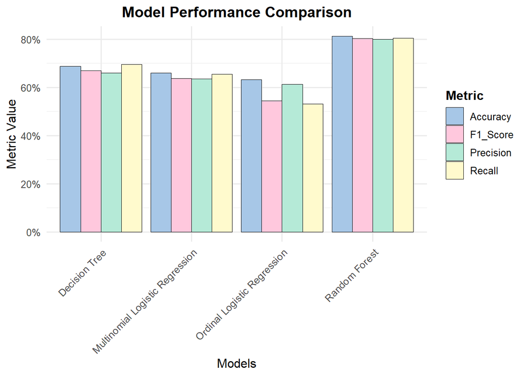

```r
library(tidyr)
library(ggplot2)

# Reshape the data frame to long format to display individually
model_results_long <- model_results %>%
  pivot_longer(
    cols = c(Accuracy, Precision, Recall, F1_Score),
    names_to = "Metric",
    values_to = "Value"
  )

custom_colors <- c(
  "Accuracy" = "#A7C7E7",
  "Precision" = "#B5EAD7",
  "Recall" = "#FFFACD",
  "F1_Score" = "#FFC8DD"
)

ggplot(model_results_long, aes(x = Model, y = Value, fill = Metric)) +
  geom_bar(stat = "identity", position = "dodge", color = "black", linewidth = 0.2) +
  labs(
    title = "Model Performance Comparison",
    x = "Models",
    y = "Metric Value"
  ) +
  theme_minimal(base_size = 12) +
  theme(
    axis.text.x = element_text(angle = 45, hjust = 1),
    plot.title = element_text(hjust = 0.5, face = "bold"),
    legend.title = element_text(face = "bold")
  ) +
  scale_fill_manual(values = custom_colors) +
  scale_y_continuous(labels = scales::percent_format(accuracy = 1))
```

Let’s compare the models accuracy to the baseline we have established before using a majority classifier.

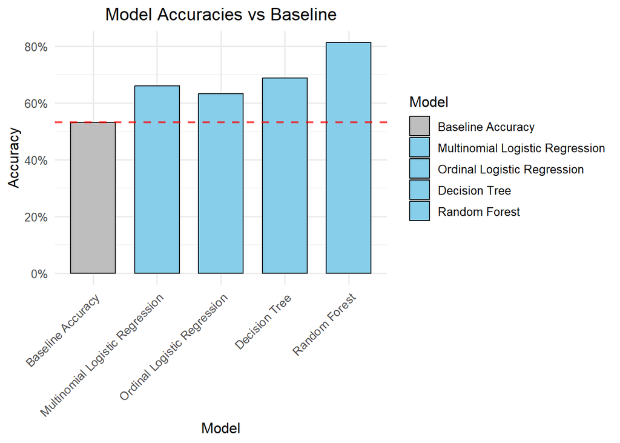

```r
library(ggplot2)

model_names <- c(
  "Baseline Accuracy",
  "Multinomial Logistic Regression",
  "Ordinal Logistic Regression",
  "Decision Tree",
  "Random Forest"
)

accuracies <- c(
  0.531,  # Baseline accuracy
  accuracy_mlogit,
  accuracy_ordinal,
  accuracy_tree,
  accuracy_forest
)

accuracy_data <- data.frame(
  Model = factor(model_names, levels = model_names),
  Accuracy = accuracies
)

ggplot(accuracy_data, aes(x = Model, y = Accuracy, fill = Model)) +
  geom_bar(stat = "identity", width = 0.7, color = "black") +
  scale_fill_manual(values = c("gray", rep("skyblue", length(model_names) - 1))) +
  labs(
    title = "Model Accuracies vs Baseline",
    x = "Model",
    y = "Accuracy"
  ) +
  geom_hline(yintercept = 0.531, linetype = "dashed", color = "red", linewidth = 0.8, alpha = 0.7) +
  theme_minimal(base_size = 12) +
  theme(axis.text.x = element_text(angle = 45, hjust = 1), plot.title = element_text(hjust = 0.5)) +
  scale_y_continuous(labels = scales::percent)+
  theme(
    plot.title = element_text(hjust = 0.5)
  )
```

We can see that all models are better than the baseline.

# Final Model and Predictors

## Final Model

The **Random Forest model** should be chosen as the final model because it achieves the highest accuracy (81.2%) and consistently strong performance across all metrics (Precision: 79.9%, Recall: 80.5%, F1 Score: 80.2%). Its ability to combine multiple decision trees allows it to capture complex relationships in the data while reducing overfitting, making it more robust and reliable for predicting the Credit Score compared to simpler models like logistic regression or a single decision tree.

## Important Predictors

Let’s take a look at the important predictors determined by the random forest model using the importance scores.

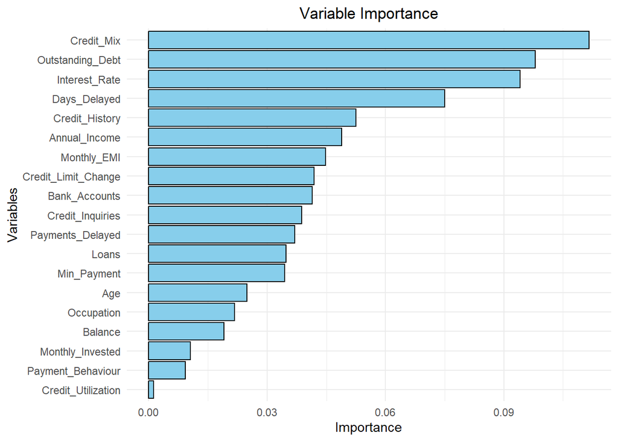

```r
library(ggplot2)

ggplot(importance_table, aes(x = reorder(Variable, Importance), y = Importance)) +
  geom_bar(stat = "identity", fill = "skyblue", color = "black") +
  coord_flip() +
  labs(
    title = "Variable Importance",
    x = "Variables",
    y = "Importance"
  ) +
  theme_minimal() +
  theme(
    plot.title = element_text(hjust = 0.5)
  )
```

**Interpretation**

The model relies most on Credit Mix, Outstanding Debt, and Interest Rate to predict Credit Score, emphasizing the importance of debt management and credit diversity in determining creditworthiness.

1. Top Variables:
   - Credit_Mix, Outstanding_Debt, and Interest_Rate are the most important predictors.
     - Credit_Mix contributes the most, indicating it strongly influences the prediction of Credit Score.
     - Outstanding_Debt and Interest_Rate are key financial factors that also significantly impact predictions.
2. Moderately Important Variables:
   - Days_Delayed, Credit_History, and Annual_Income also play a substantial role, highlighting the importance of payment behavior and financial stability.
3. Lower Importance Variables:
   - Variables like Balance, Monthly_Invested, and Credit_Utilization contribute less, suggesting they have minimal influence on the model’s performance.

## Comparison to reallife predictors

**Source**

The source of the credit score calculation information is **Investopedia**, a trusted financial education website. You can find the full explanation here:

[**Credit Score Calculation on Investopedia**](https://www.investopedia.com/ask/answers/05/creditscorecalculation.asp).

It outlines how credit scores (like FICO scores) are calculated using five main components: Payment History (35%), Amount Owed (30%), Length of Credit History (15%), New Credit (10%), and Credit Mix (10%).

**Comparing the predictors to the real deal**

We will categorize the predictor variables into the categories provided by the source:

1. Payment History (35%):
   - Delay_from_due_date: Number of days delayed for payments.
   - Num_of_Delayed_Payment: Total delayed payments.
   - Payment_of_Min_Amount: Indicates if the minimum payment was made.
   - Payment_Behaviour: Overall payment behavior.
2. Amount Owed (30%):
   - Outstanding_Debt: Total outstanding debt.
   - Credit_Utilization_Ratio: Credit used relative to available credit.
   - Num_of_Loan: Number of active loans.
   - Changed_Credit_Limit: Change in credit limits.
   - Total_EMI_per_month: Total monthly installment payments.
3. Length of Credit History (15%):
   - Credit_History_Age: Age of credit history.
4. New Credit (10%):
   - Num_Credit_Inquiries: Number of recent credit inquiries.
5. Credit Mix (10%):
   - Credit_Mix: Mix of different types of credit accounts.
6. Other (Not Used in Real-Life Calculation):
   - Age: Age of the customer.
   - Occupation: Occupation type.
   - Annual_Income: Annual income.
   - Num_Bank_Accounts: Number of bank accounts.
   - Num_Credit_Card: Number of credit cards.
   - Amount_invested_monthly: Monthly investments.
   - Monthly_Balance: Remaining monthly balance.

# Summary

## Overview

As stated in the beginning the objective of this report was the following:

“Create a machine learning model to classify a person into”Good”, “Standard” or “Poor” credit score categories based on credit-related information.”

This was successfully accomplished through the following steps:

## Suggestions for further improvements

To further enhance our credit score prediction models, several strategies could be explored:

1. **Additional Data Sources**:  
   Integrate new datasets and information to capture a broader picture of financial behavior:
   - Internet of Things (IoT): Data from connected devices, such as smart payment tools or spending habits through wearable tech, could provide insights and give our customers a realtime adjustment to their credit score via an app.
   - Transaction Data: Detailed bank transaction histories or spending categories (e.g., groceries, utilities, luxury items) can help differentiate financial health across credit score groups.
   - Lifestyle Indicators: Include data like utility bill payments, rental histories, or subscription behaviors, which are not traditionally included but can reflect financial responsibility.
2. **Feature Engineering**:  
   Create new variables that reveal complex relationships in the data, such as:
   - Debt-to-Income Ratio: Ratio of outstanding debt to annual income.
   - Payment Timeliness Index: Average days delayed divided by total credit history.
   - Utilization Trends: Changes in credit utilization ratio over time.
3. **Hyperparameter Tuning**:  
   Fine-tune Random Forest and other models using methods like grid search or Bayesian optimization to optimize key parameters (e.g., tree depth, number of trees).
4. **Ensemble Methods**:  
   Explore advanced ensemble techniques such as:
   - Gradient Boosting (e.g., XGBoost, LightGBM): Effective for handling complex, non-linear relationships in large datasets.
   - Stacking: Combine predictions from multiple models to enhance performance.
5. **Data Augmentation**:  
   Collect or simulate additional credit-related data to improve model generalization, including:
   - Loan-Specific Features: Loan types (e.g., mortgage, student, auto), interest rates, and loan tenures.
   - Behavioral Insights: Spending patterns, saving habits, or investment frequency.